# **Projeto Final - ICD**

### **Análise das correlações dos estados**

Como foi visto nos gráficos acima sobre a correlação, o estado que tem seu valor mais alto em ambas situações foi o Maranhão:

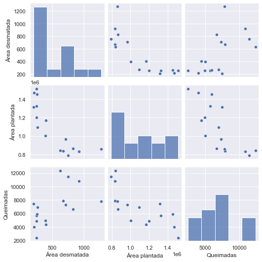

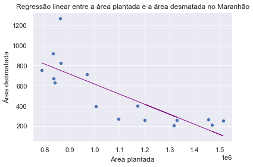

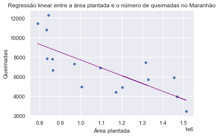

### **Análise para todos estados entre a área plantada e área desmatada:**

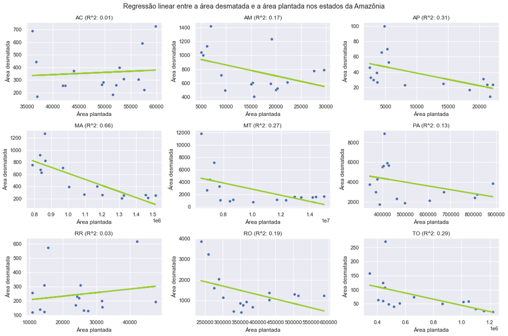

### **Análise para todos estados entre a área plantada e o número de queimadas:**

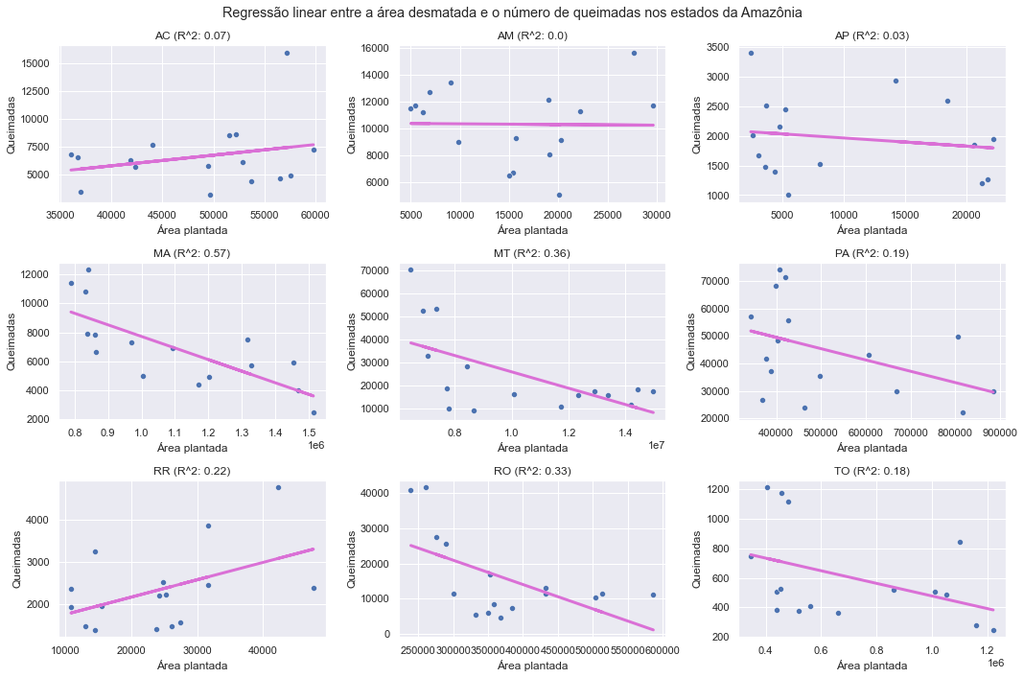

### **Fazendo as regressões apenas com os dados da esquerda:**

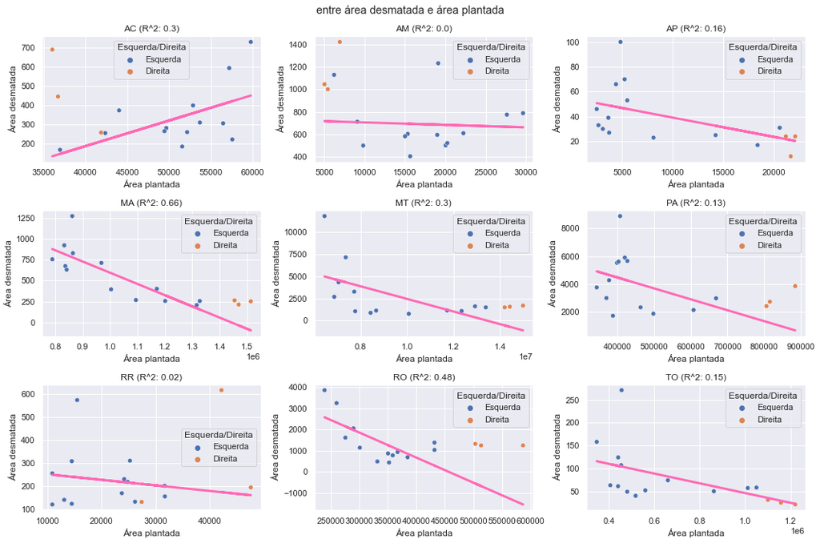

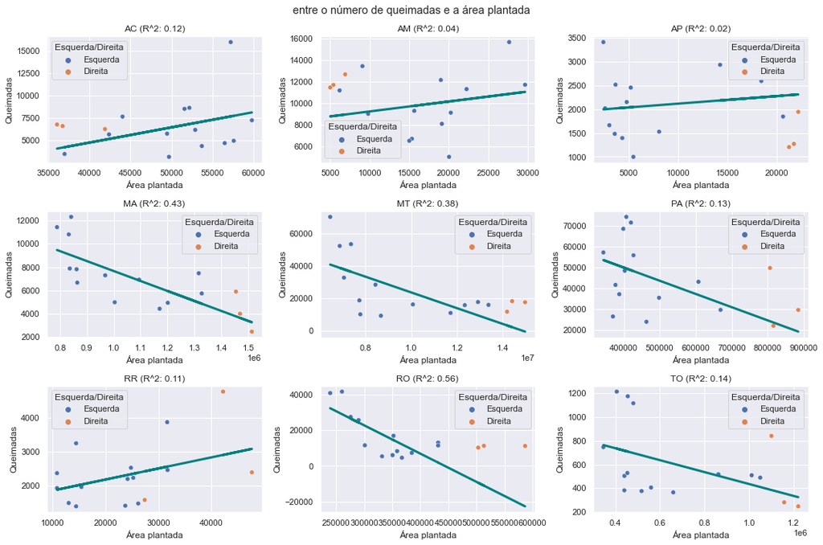

Observando as diferenças entre a reta da regressão linear e os pontos verdadeiros do scatterplot, podemos concluir:

- Para alguns estados, como Rondônia e Mato Grosso, os pontos da direita parecem estar indo contra a tendência da esquerda (de queda).
- No entanto, para alguns outros estados, os pontos da direita estão indo conforme os da esquerda, a favor da tendência.

## **5. Conclusão**

Um dos desafios enfrentados em análise de dados perpassa justamente na completude e corretude dos mesmos. Dados incompletos ou incorretos podem passar a sensação de ausência de correlação não necessariamente verdadeira. Em nossas análises nos deparamos com esse desafio, onde os datasets estudados não continham informações de todos os anos de todos os governos brasileiros (especialmente do último). Embora seja de conhecimento público do crescimento expressivo do desmatamento e queimadas nos útltimos anos, não conseguimos provar a associação da ideologia governamental com o aumento da área desmatada.